# Beer Advocate: ABV and quality ratings

Greg Rousis

For this activity, download the data file at this location to the `data` subfolder in your `participation` folder. This dataset contains information about different catagories of beer as rated on <beeradvocate.com>. The data are originally from [here](http://scottjanish.com/relationship-of-abv-to-beer-scores/).

```r
url <- "https://raw.githubusercontent.com/USF-Psych-DataSci/Classroom/master/data/beer-advocate.csv"
```

The dataset contains 3 variables:

1. Beer category
2. Average alcohol by volume (ABV) in percentage (%)
3. Average quality rating (rAVG) on a 1–5 scale

You should write a script to do the following:

1. Download the dataset with an appropriate filename.
2. Import the dataset into R. Be sure to check for any importing problems and correct as needed.

```r
if ( !dir.exists( here::here("participation", "data") ) ) {
  dir.create( here::here("participation", "data"), recursive = TRUE )
}

beer_data <- read_csv(url,
                      col_types = cols(
                        `Beer Category` = col_character(),
                        `Average Abv` = col_double(),
                        rAVG = col_double()
                      )
)
beer_data$`Average ABV` <- as.double(beer_data$`Average ABV`)
beer_data
```

```
## # A tibble: 102 x 3
##    `Beer Category`       `Average ABV`  rAVG
##    <chr>                         <dbl> <dbl>
##  1 Low Alcohol Beer               0.96  2.5
##  2 Kvass                          1.07  3.19
##  3 Light Lager                    4.04  2.67
##  4 English Dark Mild Ale          4.07  3.69
##  5 Berliner Weissbier             4.15  3.81
##  6 English Bitter                 4.27  3.49
##  7 Faro                           4.58  3.64
##  8 Gose                           4.62  3.8
##  9 English Pale Ale               4.71  3.49
## 10 Euro Pale Lager                4.84  2.86
## # ... with 92 more rows
```

```r
write_csv(
  beer_data,
  here::here("participation", "data", "beer_data.csv")
)
```

3. Make a figure illustrating the relationship between ABV and beer quality.

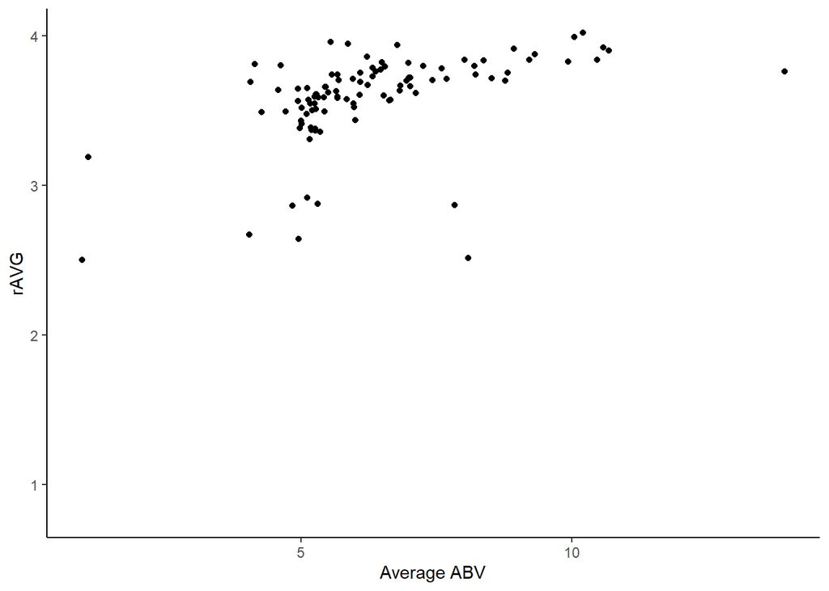

```r
ggplot(beer_data) +
  aes(x = `Average ABV`,
      y = rAVG) +
  geom_jitter() +
  theme_classic()
```

4. Compute a summary table with the mean and SD of each variable, along with their correlation.

```r
beer_data %>%
summarize(across(
  where(is.double),
  list(
    mean = ~mean(.x, na.rm = TRUE),
    sd = ~sd(.x, na.rm = TRUE)),
  .names = "{.col}.{.fn}")
)
```

```
## # A tibble: 1 x 4
##   `Average ABV.mean` `Average ABV.sd` rAVG.mean rAVG.sd
##                <dbl>            <dbl>     <dbl>   <dbl>
## 1               6.33             1.89      3.56   0.410
```

```r
beer_data %>%
  select(-`Beer Category`) %>%
  cor(use = "pairwise.complete.obs")
```

```
##             Average ABV      rAVG
## Average ABV   1.0000000 0.4845617
## rAVG          0.4845617 1.0000000
```

5. Describe the results.

**Answer:** I couldn’t figure out how to get the correlation and summary stats in one table, but in any case, there is a pretty robust association between alcohol content and average rating. The more alcohol the beer has, the more people tended to like it. It could be because, when rating the highly alcoholic beer, they’re drunk, thus making it more likely that they’ll say they enjoy it. There does seem to be a ceiling effect though - lots of high ratings, but very few low ratings.